# Assignment - Week 08

Yara Roth

2026-04-29

# Setup

```r
suppressPackageStartupMessages({
  library(epiwraps)
  library(ggplot2)
  library(AnnotationHub)
  library(ensembldb)
  library(edgeR)
  library(rtracklayer)
  library(BiocParallel)
  library(bsseq)
  library(DMRcate)
})
library(rstudioapi)
setwd(dirname(rstudioapi::getActiveDocumentContext()$path))
dir.create("data")
```

# Methylation level of Genes in top 5 DMRs (Question 1)

To look at the methylation levels of the genes that are located within the top 5 DMR I will do the following approach:  
1.) Extract the DMRs - meaninig regions where CpG methylation is significantly different between ESC and astrocytes  
2.) Rank DMRs  
3.) Find the genes that overlap with these 5 DMR regions  
4.) Plot the heatmap - showing the methylation of these genes in each sample

```r
options(timeout = 6000)
download.file("https://ethz-ins.org/content/w11_practical.zip", "data/w08_practical.zip")
unzip("data/w08_practical.zip", exdir="data")
```

First we will load the BSseq object that contains the bisulfite sequencing data from ESC and astrocytes and create the design matrix.

```r
bs <- readRDS("data/ESC_astrocytes_BSseq.rds")

# remove CpGs with zero coverage
bs <- bs[rowSums(assay(bs,"Cov")>0)==ncol(bs),]

# create design matrix
design <- model.matrix(~celltype, data=pData(bs))
methdesign <- modelMatrixMeth(design)
bs <- BSmooth(bs, BPPARAM=MulticoreParam(4, progress=FALSE))
bs
```

```
## An object of type 'BSseq' with
##   732301 methylation loci
##   4 samples
## has been smoothed with
##   BSmooth (ns = 70, h = 1000, maxGap = 100000000)
## All assays are in-memory
```

Then we will first run the statistical test on each CpG position to identify the individual CpGs that are significantly different methylated between ESC and astrocytes.

```r
seqAnnot <- sequencing.annotate(bs, methdesign, all.cov=TRUE, coef="celltypeastrocytes")
```

```
## Filtering out all CpGs where at least one sample has zero coverage...
```

```
## Processing BSseq object...
```

```
## Transforming counts...
```

```
## Fitting model...
```

```
## Your contrast returned 45364 individually significant CpGs. We recommend the default setting of pcutoff in dmrcate().
```

Then we use dmrcate to cluster the individual CpGs (that are significantly different methylated in between ESC and astrocytes) together in regions.

```r
dmrcateRes <- dmrcate(seqAnnot, C=2, min.cpgs=5)
```

[output not shown]

[output not shown]

[output not shown]

[output not shown]

[output not shown]

[output not shown]

[output not shown]

[output not shown]

[output not shown]

[output not shown]

[output not shown]

[output not shown]

[output not shown]

[output not shown]

[output not shown]

[output not shown]

[output not shown]

[output not shown]

[output not shown]

[output not shown]

[output not shown]

[output not shown]

[output not shown]

[output not shown]

[output not shown]

```
## Demarcating regions...
```

```
## Done!
```

```r
dmrRanges <- extractRanges(dmrcateRes, genome="hg19")
```

```
## see ?DMRcatedata and browseVignettes('DMRcatedata') for documentation
```

```
## loading from cache
```

```r
dmrRanges
```

```
## GRanges object with 2580 ranges and 8 metadata columns:
##          seqnames              ranges strand |   no.cpgs min_smoothed_fdr
##             <Rle>           <IRanges>  <Rle> | <integer>        <numeric>
##      [1]    chr19     2250311-2253429      * |        94                0
##      [2]    chr13 109792493-109793503      * |        79                0
##      [3]     chr8     9008196-9009307      * |        79                0
##      [4]    chr19   48945963-48947530      * |        75                0
##      [5]    chr11       279433-280820      * |        54                0
##      ...      ...                 ...    ... .       ...              ...
##   [2576]     chrX   69672524-69672590      * |         6      7.82359e-15
##   [2577]    chr19   53893297-53893454      * |        11      8.14236e-15
##   [2578]     chr6   35027087-35027146      * |         6      8.20942e-15
##   [2579]    chr19   12707818-12707907      * |         5      9.20759e-15
##   [2580]    chr19     2469713-2469775      * |         5      9.82887e-15
##              Stouffer       HMFDR       Fisher   maxdiff  meandiff
```

[output cut: 27 more lines]

Now we will extract the DMR located in chromosome 1 and select only the top 5.

```r
dmr_top <- dmrRanges[seqnames(dmrRanges) == "chr1"]
dmr_top <- dmr_top[order(dmr_top$HMFDR)[1:5]]
# dmr_top_2 <- dmr_top[order(dmr_top$meandiff)[1:5]]
```

In the next step we will extract the genes that overlap the DMR and plot their methylation levels in a heatmap.

```r
genes <- readRDS("data/hg19_chr1_genes.rds")
genes_dmr <- subsetByOverlaps(genes, dmr_top, ignore.strand=TRUE, type="any")
genes_dmr
```

```
## GRanges object with 1 range and 2 metadata columns:
##        seqnames              ranges strand |     gene_id      symbol
##           <Rle>           <IRanges>  <Rle> | <character> <character>
##   CR1L     chr1 207818458-207898053      + |        1379        CR1L
##   -------
##   seqinfo: 93 sequences (1 circular) from hg19 genome
```

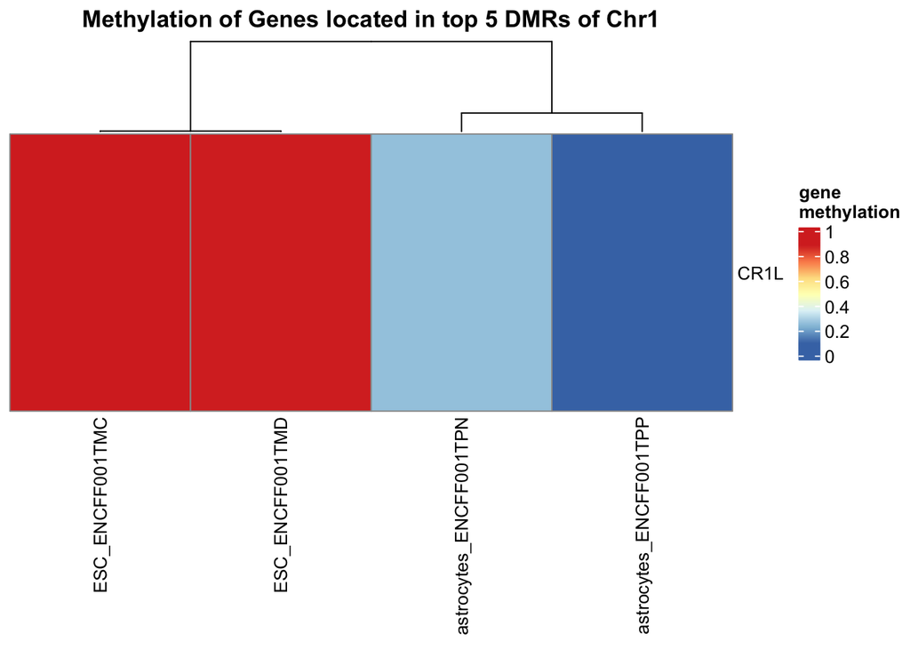

```r
met <- getMeth(bs, regions=genes_dmr, what="perRegion")
rownames(met) <- genes_dmr$symbol
pheatmap(met, name="gene\nmethylation",main="Methylation of Genes located in top 5 DMRs of Chr1")
```

Interestingly, when I look at the overlapping genes of the `dmr_top` object, I see three genes, namely CR1L, CD46P1, and RP11-431K24.1. However, only CR1L can be found in the hg19 genes. That is also the reason that only one gene is visible on the heatmap, when using the `subsetByOverlaps()` function.

## Methylation and ATAC comparison (Question 2)

First we will download the ATAC data. This file contains differentially accessible regions in between ESC and astrocytes.

```r
download.file("https://www.ethz-ins.org/content/ATAC_AstroVsESC_subset.rds", "data/ATAC_AstroVsESC_subset.rds")
```

Then we will load both DMRs and ATAC datasets.

```r
dmr <- readRDS("dmr.rds")
atac <- readRDS("data/ATAC_AstroVsESC_subset.rds")
```

Fist, I will get if we have ovelraps between DMRs and ATAC peaks.

```r
overlaps <- findOverlaps(dmr, atac)
overlapping_dmrs <- dmr[queryHits(overlaps)]
overlapping_atac <- atac[subjectHits(overlaps)]

pct_dmr <- round(length(unique(queryHits(overlaps))) / length(dmr) * 100, 2)
pct_atac <- round(length(unique(subjectHits(overlaps))) / length(atac) * 100, 2)

cat("DMRs overlapping with ATAC peaks:", pct_dmr, "%\n")
```

```
## DMRs overlapping with ATAC peaks: 97.64 %
```

```r
cat("ATAC peaks overlapping with DMRs:", pct_atac, "%\n")
```

```
## ATAC peaks overlapping with DMRs: 100 %
```

```r
cat("Total overlapping regions:", length(overlaps), "\n")
```

```
## Total overlapping regions: 5279
```

All ATAC peaks overlapp with the DMRs, and 97.64% of DMRS overlap with the ATAC peaks. Meaning that these two modalities show a very high agreement.

To further quantify this agreement, we can calculate the correlation between the two effect sizes (logFC for ATAC and meandiff for DMR). This allows us to see if hypomethylation is actually associated with more accessible chromatin or not.

If logFC (from the ATAC data) is > 0, the chromatin is more accesible in astrocytes compared to ESC.

If the meandiff (from the DMR data) is > 0, the DNA is more methylated in the astrocytes compared to ESC.

We would expect more accesible chromatin to correlate with hypomethylated DNA. And less accesible chromatin with hypermethylated DNA.  
Therefore the top-left quadrant and bottom right quadrant are in agreement.

```r
corr_df <- data.frame(
  meandiff = overlapping_dmrs$meandiff,
  logFC = overlapping_atac$logFC
)

# Add agreement status (green if concordant)
corr_df$agreement <- ((corr_df$meandiff < 0 & corr_df$logFC > 0) |
                      (corr_df$meandiff > 0 & corr_df$logFC < 0))

cor(corr_df$meandiff, corr_df$logFC)
```

```
## [1] -0.1976229
```

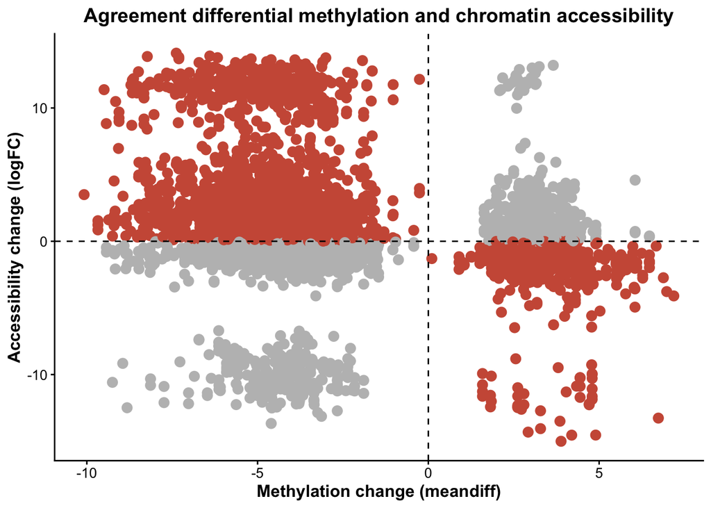

```r
ggplot(corr_df, aes(meandiff, logFC, color = agreement)) +
  geom_point(size = 3) +
  geom_vline(xintercept = 0, linetype = "dashed", color = "black") +
  geom_hline(yintercept = 0, linetype = "dashed", color = "black") +
  scale_color_manual(values = c("FALSE" = "grey", "TRUE" = "coral3"), guide = "none") +
  labs(title = "Agreement differential methylation and chromatin accessibility",
       x = "Methylation change (meandiff)",
       y = "Accessibility change (logFC)") +
  theme_classic() +
  theme(plot.title = element_text(size = 14, face = "bold", hjust = 0.5),
        axis.title = element_text(size = 12, face = "bold"),
        axis.text = element_text(size = 10))
```

We can see that the largest proportion of points are located in the top-left and bottom right quadrants, indicating an agreement between changes in methylation and accesiblity in the majority of the region.  
- hypermethylation <-> less accesible chromatin  
- hypomethylation <-> more accesible chromatin  
However, a notable fraction of datapoints are located located in the non-agreeing quadrants. This could indicate that these regions regulate their accessbility over other regulatory mechanism than methylation.